# Instacart Market Basket Analysis

Ting Yang, Jiaming Huang, Manunpat Sirijaturaporn, and Arturo García Luna Beltrán

20 mayo, 2022

## **Supervised Learning**

### **Data Preparation for Models**

Before starting applying the models to the data, we have decided to aggregate the column called `id_orders` by department, so we could know the number of products purchased by department. In addition, we have considered to keep the column `order_dow`, to identify on which day of the week an order was purchased.

After creating this new table, we converted the column `order_dow` from numeric(int) to categorical values(factor), and to understand better this values, we change the integer values to the name of the day of the week. For example: The value “0” was transformed to “Sunday”, “1” to “Monday”, “2” to “Tuesday”, and so on.

### **Decision Trees - Classification**

Decision trees are algorithms that recursively search the space for the best boundary possible, until we unable them to do so (Ivo Bernardo,2021). The basic functionality of decision trees is to split the data space into rectangles, by measuring each split. The main goal is to minimize the impurity of each split from the previous one.

Our goal is to determine which day of the week a given order will be placed. Due to the fact that we have transformed the column `order_dow` as a factor with categorical values, we will apply decision trees with classification task. In addition, we will apply this type of model on 3 different approaches:

- One day of the week - Unbalanced data
- One day of the week - Balanced data with Sub-sampling and Cross-Validation
- Weekdays and Weekend - Balanced data with Sub-sampling and Cross-Validation

> **One day of the week - Unbalanced data**

For this approach we want to measure the accuracy of the model with the unbalanced data. In addition, it will be interesting to see which departments were considered the best to split the data into days of the week to later be compared to a balanced data with cross-validation (second approach).

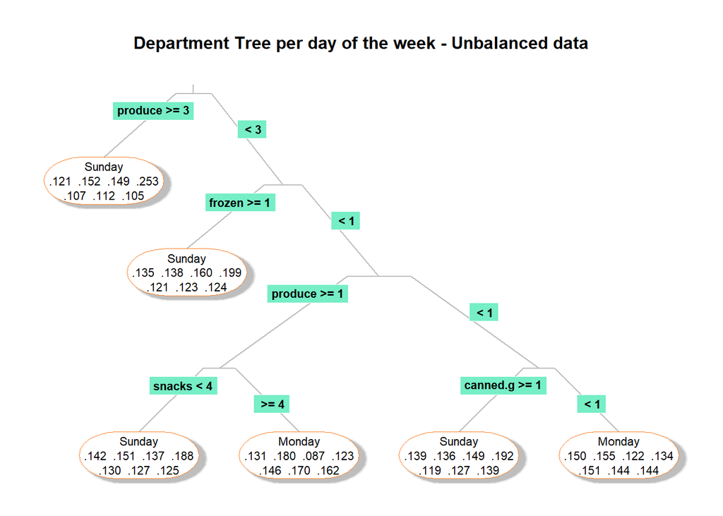

According to the pruned tree, we observe that the department **produce** have the most relevance within the departments, this could be influenced by the fact that this department has the highest number of products purchased in our data set. Furthermore, the tree show us that with an amount of products purchased higher or equal than 3, the model will classify the day of the week as Sunday, if it is lower than 3 the tree will split into another node containing the **frozen** department.

Likewise, the same procedure will be consider for this node and the following, they will start from the previous node and will try to minimize the impurity at each split. It should be noted that we cannot observed on the terminal nodes all the days of the week, because of the way in which the trees are generated. For the same reason, we expect on the prediction of the test set, a prediction value of “0” on the days of the week different to Sunday and Monday.

```
#> Confusion Matrix and Statistics
#>
#>            Reference
#> Prediction  Friday Monday Saturday Sunday Thursday Tuesday Wednesday
#>   Friday         0      0        0      0        0       0         0
#>   Monday       694    706      578    650      708     685       661
#>   Saturday       0      0        0      0        0       0         0
#>   Sunday      2787   3228     3202   4843     2483    2538      2476
#>   Thursday       0      0        0      0        0       0         0
#>   Tuesday        0      0        0      0        0       0         0
#>   Wednesday      0      0        0      0        0       0         0
#>
#> Overall Statistics
#>
#>                Accuracy : 0.211
#>                  95% CI : (0.207, 0.216)
#>     No Information Rate : 0.209
#>     P-Value [Acc > NIR] : 0.2
#>
#>                   Kappa : 0.016
#>
#>  Mcnemar's Test P-Value : NA
#>
#> Statistics by Class:
#>
#>                      Class: Friday Class: Monday Class: Saturday
#> Sensitivity                  0.000        0.1795           0.000
#> Specificity                  1.000        0.8217           1.000
#> Pos Pred Value                 NaN        0.1508             NaN
#> Neg Pred Value               0.867        0.8503           0.856
#> Prevalence                   0.133        0.1499           0.144
#> Detection Rate               0.000        0.0269           0.000
#> Detection Prevalence         0.000        0.1784           0.000
#> Balanced Accuracy            0.500        0.5006           0.500
#>                      Class: Sunday Class: Thursday Class: Tuesday
#> Sensitivity                  0.882           0.000          0.000
#> Specificity                  0.194           1.000          1.000
#> Pos Pred Value               0.225             NaN            NaN
#> Neg Pred Value               0.861           0.878          0.877
#> Prevalence                   0.209           0.122          0.123
#> Detection Rate               0.185           0.000          0.000
#> Detection Prevalence         0.822           0.000          0.000
#> Balanced Accuracy            0.538           0.500          0.500
#>                      Class: Wednesday
#> Sensitivity                      0.00
#> Specificity                      1.00
#> Pos Pred Value                    NaN
#> Neg Pred Value                   0.88
#> Prevalence                       0.12
#> Detection Rate                   0.00
#> Detection Prevalence             0.00
#> Balanced Accuracy                0.50
```

> **One day of the week - Balanced data with Sub-sampling and Cross-Validation**

Now for this approach, we will balanced the data with sub-sampling and make the overall score more robust by applying to the model a cross-validation technique, this will help us to find the best set of hyperparameters.

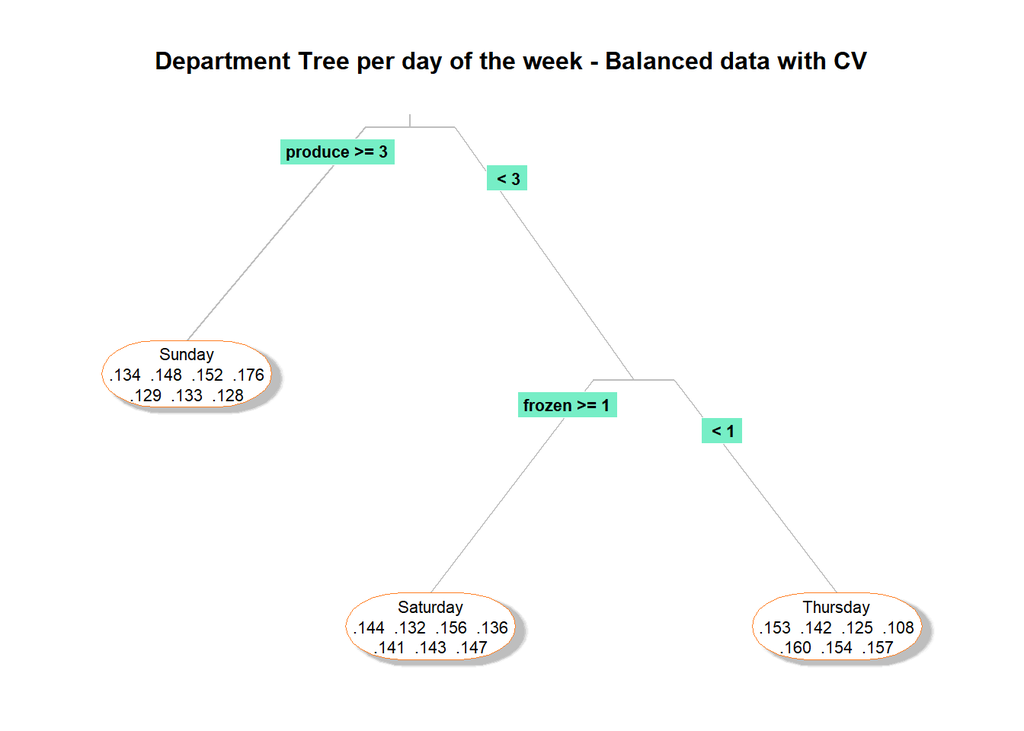

```
#>  .outcome  Fri Mon Sat Sun Thu Tue Wed                                    cover
#>  Saturday [.14 .13 .16 .14 .14 .14 .15] when produce <  3 & frozen >= 1     18%
#>    Sunday [.13 .15 .15 .18 .13 .13 .13] when produce >= 3                   44%
#>  Thursday [.15 .14 .13 .11 .16 .15 .16] when produce <  3 & frozen <  1     38%
```

The left column (*.outcome*) of the rules show the day that was selected for the terminal node (*the one with the highest probability*) and next to it the probability of each day of the week for the department selected. In this case for the last rule it seems that Wednesday and Thursday have the same probability because of the rounding, but Thursday its **0.3%** above Wednesday, this can be seen from the tree plot.

```
#> Confusion Matrix and Statistics
#>
#>            Reference
#> Prediction  Friday Monday Saturday Sunday Thursday Tuesday Wednesday
#>   Friday         0      0        0      0        0       0         0
#>   Monday         0      0        0      0        0       0         0
#>   Saturday     678    645      751    904      595     587       583
#>   Sunday      1454   1797     1768   2992     1235    1291      1259
#>   Thursday    1349   1492     1261   1597     1361    1345      1295
#>   Tuesday        0      0        0      0        0       0         0
#>   Wednesday      0      0        0      0        0       0         0
#>
#> Overall Statistics
#>
#>                Accuracy : 0.195
#>                  95% CI : (0.19, 0.199)
#>     No Information Rate : 0.209
#>     P-Value [Acc > NIR] : 1
#>
#>                   Kappa : 0.035
#>
#>  Mcnemar's Test P-Value : NA
#>
#> Statistics by Class:
#>
#>                      Class: Friday Class: Monday Class: Saturday
#> Sensitivity                  0.000          0.00          0.1987
#> Specificity                  1.000          1.00          0.8223
#> Pos Pred Value                 NaN           NaN          0.1583
#> Neg Pred Value               0.867          0.85          0.8591
#> Prevalence                   0.133          0.15          0.1441
#> Detection Rate               0.000          0.00          0.0286
#> Detection Prevalence         0.000          0.00          0.1808
#> Balanced Accuracy            0.500          0.50          0.5105
#>                      Class: Sunday Class: Thursday Class: Tuesday
#> Sensitivity                  0.545          0.4265          0.000
#> Specificity                  0.576          0.6382          1.000
#> Pos Pred Value               0.254          0.1403            NaN
#> Neg Pred Value               0.827          0.8894          0.877
#> Prevalence                   0.209          0.1216          0.123
#> Detection Rate               0.114          0.0519          0.000
#> Detection Prevalence         0.450          0.3697          0.000
#> Balanced Accuracy            0.560          0.5324          0.500
#>                      Class: Wednesday
#> Sensitivity                      0.00
#> Specificity                      1.00
#> Pos Pred Value                    NaN
#> Neg Pred Value                   0.88
#> Prevalence                       0.12
#> Detection Rate                   0.00
#> Detection Prevalence             0.00
#> Balanced Accuracy                0.50
```

From the confusion matrix we observe a better result between the sensitivity and specificity across the classes, if we compare the previous model with this one, we notice that on the class Sunday the values of the sensitivity changed from **0.882** to **0.545**, and for the specificity from **0.194** to **0.576**. As expected, the Accuracy has decreased from **0.211** to **0.195**, meaning that the model have (`(0.195 - (1/7))= 0.052`) around **5%** of accuracy per day of the week, but the Balanced Accuracy is better. This model would be preferred than the one used with unbalanced data.

> **Weekdays and Weekend - Balanced data with Sub-sampling and Cross-Validation**

For the Final approach we transformed the levels of the column `order_dow` into two, one for the days during the week and the other for the weekend. On top of that we balanced our levels “weekday” and “weekend” and consider a Cross-Validation to train the model.

We try to plot the final tree computed by the model, but it was not possible to interpret it, due to the overlapping nodes shown in the graph, but we could see that the departments **produce, frozen** and **meat.seafood**, were among the first splits.

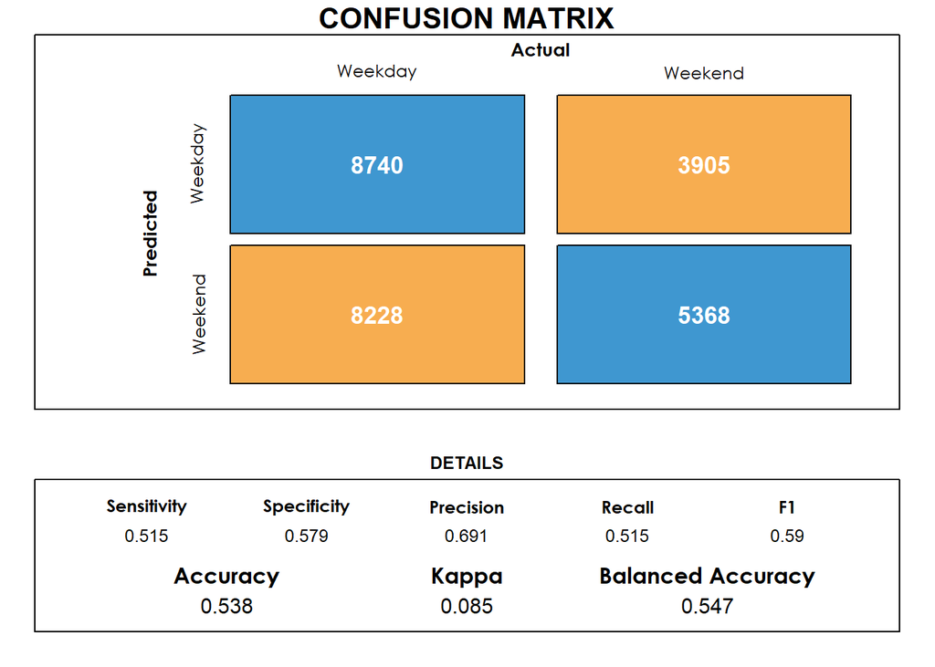

The results of the confusion matrix show us a well balanced data from what we can observed in the sensitivity and specificity. The Accuracy of the model is similar comparing it with the other two approaches, the model have (`(0.538 - (1/2))= 0.038`) just below **4%** of accuracy. Overall, all different approaches have a low score at predicting the day of the week based on the department purchases from previous orders.

### **Random Forest**

Random Forest (RF) are algorithms of a set of decision trees that will produce a final prediction with the average outcome of the set of trees considered (*user can define the amount of trees and the number of variables for each node*). One of the reasons that we decided to test this method is because RF are considered to be more stable than Decision Trees; more trees better performance, but certain advantages come at a price. RF slow down the computation speed and cannot be visualize, however, we will look at the results for later comparison (Saikumar Talari, 2022).

> **Weekdays and Weekend - Balanced data with Sub-sampling and Cross-Validation**

For this method we will consider the same approach as the last one of Classification Tree. We faced some computation speed problems while running the model, for that reason we decided to considered only 10,000 orders to reduce the waiting time.

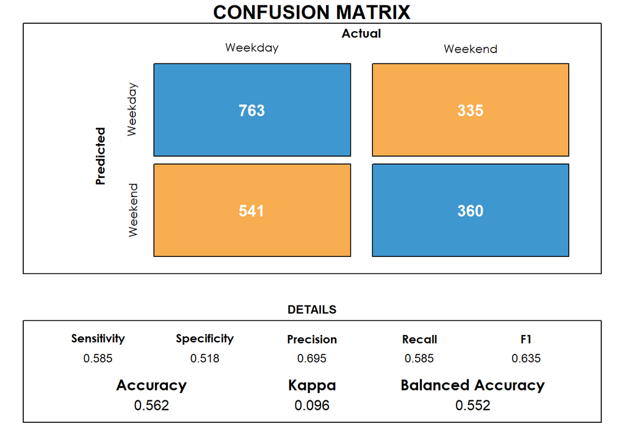

As expected, the Accuracy of the model is higher than the Classification Tree as well as Cohen’s Kappa and the balanced accuracy. This model would be preferred at predicting “weekday” and “weekend” as it has better results.

### **Multinomial Logistic Regression**

Our goal is to predict the day of the week that the order will be placed according to the product composition in the order. Since there are 7 days in a week so it is not a binary logistic regression problem but a multinomial logistic regression.

##### 1.Train and Test set

##### 2.Build the Model

We use the day 0 as the reference level. To build the model, we use the number of products in each department of the order as explanatory variables.

##### 3.Check the Score of the Model

```
#> Confusion Matrix and Statistics
#>
#>           Reference
#> Prediction    0    1    2    3    4    5    6
#>          0 5220 3737 3037 2848 2888 3310 3680
#>          1   60  111  101   93   96   81   57
#>          2    0    0    1    0    0    0    0
#>          3   16   18   15   14   16   12   13
#>          4    5    4    2    5    8    6    8
#>          5   91   81   82   91  103  110   91
#>          6   24   20   15    9   17   21   25
#>
#> Overall Statistics
#>
#>                Accuracy : 0.209
#>                  95% CI : (0.204, 0.214)
#>     No Information Rate : 0.206
#>     P-Value [Acc > NIR] : 0.134
#>
#>                   Kappa : 0.008
#>
#>  Mcnemar's Test P-Value : <2e-16
#>
#> Statistics by Class:
#>
#>                      Class: 0 Class: 1 Class: 2 Class: 3 Class: 4
#> Sensitivity            0.9638  0.02795 3.07e-04 0.004575 0.002558
#> Specificity            0.0637  0.97809 1.00e+00 0.996118 0.998702
#> Pos Pred Value         0.2112  0.18531 1.00e+00 0.134615 0.210526
#> Neg Pred Value         0.8712  0.84947 8.76e-01 0.883465 0.880934
#> Prevalence             0.2064  0.15132 1.24e-01 0.116607 0.119198
#> Detection Rate         0.1989  0.00423 3.81e-05 0.000533 0.000305
#> Detection Prevalence   0.9420  0.02283 3.81e-05 0.003963 0.001448
#> Balanced Accuracy      0.5137  0.50302 5.00e-01 0.500346 0.500630
#>                      Class: 5 Class: 6
#> Sensitivity           0.03107 0.006453
#> Specificity           0.97626 0.995261
#> Pos Pred Value        0.16949 0.190840
#> Neg Pred Value        0.86598 0.852591
#> Prevalence            0.13490 0.147626
#> Detection Rate        0.00419 0.000953
#> Detection Prevalence  0.02473 0.004992
#> Balanced Accuracy     0.50367 0.500857
```

#### improve the model

According to the confusion matrix, the accurancy is low and there is a big difference between sensitivity and specificity. We try to balance the data and use a cross-validation to improve the model accurancy.

##### 1.balance the data

Check the unbalance of classes frequencies.

```
#>
#>     0     1     2     3     4     5     6
#> 22049 15701 12866 12627 12831 13866 15027
```

##### 2.subsampling and cross-validation

We try the cross-validation with the subsampling data, but the data set is big and it takes a very long time to run it so we decide not to include the cross-validation.

subsampling the data without cross-validation

```
#>
#>     0     1     2     3     4     5     6
#> 12627 12627 12627 12627 12627 12627 12627
```

```
#> Confusion Matrix and Statistics
#>
#>           Reference
#> Prediction    0    1    2    3    4    5    6
#>          0 1895 1110  794  696  735  810 1116
#>          1  648  493  345  314  285  403  363
#>          2  460  388  337  353  370  363  379
#>          3  666  655  572  563  565  627  563
#>          4  552  445  417  441  442  468  476
#>          5  472  412  347  315  323  394  394
#>          6  723  468  441  378  408  475  583
#>
#> Overall Statistics
#>
#>                Accuracy : 0.179
#>                  95% CI : (0.175, 0.184)
#>     No Information Rate : 0.206
#>     P-Value [Acc > NIR] : 1
#>
#>                   Kappa : 0.032
#>
#>  Mcnemar's Test P-Value : <2e-16
#>
#> Statistics by Class:
#>
#>                      Class: 0 Class: 1 Class: 2 Class: 3 Class: 4
#> Sensitivity            0.3499   0.1242   0.1036   0.1840   0.1413
#> Specificity            0.7474   0.8941   0.8994   0.8426   0.8789
#> Pos Pred Value         0.2648   0.1729   0.1272   0.1337   0.1364
#> Neg Pred Value         0.8155   0.8513   0.8764   0.8867   0.8832
#> Prevalence             0.2064   0.1513   0.1240   0.1166   0.1192
#> Detection Rate         0.0722   0.0188   0.0128   0.0215   0.0168
#> Detection Prevalence   0.2727   0.1086   0.1010   0.1605   0.1235
#> Balanced Accuracy      0.5486   0.5091   0.5015   0.5133   0.5101
#>                      Class: 5 Class: 6
#> Sensitivity             0.111   0.1505
#> Specificity             0.900   0.8707
#> Pos Pred Value          0.148   0.1677
#> Neg Pred Value          0.867   0.8554
#> Prevalence              0.135   0.1476
#> Detection Rate          0.015   0.0222
#> Detection Prevalence    0.101   0.1325
#> Balanced Accuracy       0.506   0.5106
```

### **Logistic Regression**

In order to further improve our model quality, we think about aggregating the classes of the day of week. Usually the buying behavior is different between weekday and weekend. So we separate the day of week into two classes weekday and weekend.

Now the outcome variable has only two categories so we can use the binomial logistic regression.

According to the confusion matrix the balanced accuracy and kappa are higher.

```
#> Confusion Matrix and Statistics
#>
#>           Reference
#> Prediction weekday weekend
#>    weekday   10576    4872
#>    weekend    6376    4418
#>
#>                Accuracy : 0.571
#>                  95% CI : (0.565, 0.577)
#>     No Information Rate : 0.646
#>     P-Value [Acc > NIR] : 1
#>
#>                   Kappa : 0.096
#>
#>  Mcnemar's Test P-Value : <2e-16
#>
#>             Sensitivity : 0.624
#>             Specificity : 0.476
#>          Pos Pred Value : 0.685
#>          Neg Pred Value : 0.409
#>              Prevalence : 0.646
#>          Detection Rate : 0.403
#>    Detection Prevalence : 0.589
#>       Balanced Accuracy : 0.550
#>
#>        'Positive' Class : weekday
#>
```

## References

Ivo Bernardo, Classification Decision Trees, Easily Explained, Aug 30, 2021: https://towardsdatascience.com/classification-decision-trees-easily-explained-f1064dde175e

Saikumar Talari, Random Forest® vs Decision Tree: Key Differences, February 18, 2022: https://www.kdnuggets.com/2022/02/random-forest-decision-tree-key-differences.html#:~:text=The%20critical%20difference%20between%20the,work%20according%20to%20the%20output.